```r
#Initialise
# - Load in EWCE results
# - Load in Human Phenotype Ontology data
# - Download / load required packages

load(params$results_data) #Load results
library(ggplot2)
library(stringr)
library(tidyverse)
library(cowplot)
library(ontologyIndex)
library(reshape2)
library(ontologyPlot)
library(scales)
genedata = read.delim(phenotype_to_genes_txt_file, skip =1) #HPO annotation
colnames(genedata) = c("ID", "Phenotype", "EntrezID", "Gene", "Additional", "Source", "LinkID")
hpo <- get_OBO("hp.obo", propagate_relationships = "is_a", extract_tags = "minimal") #Loading hpo data within ontologyIndex
children <- hpo$children
children <- children[!is.na(children)]
parents <- hpo$parents
parents <- parents[!is.na(parents)]
```

## Introduction

On the 26th of January 2021 I ran the Expression Weighted Cell-Type Enrichment (EWCE) package on the ‘Tabula Muris’ compendium of single cell RNA sequencing (ssRNAseq) data. The 120 cell types making up the original data were sorted into 38 more general groups representing similar populations. (E.g. “Epithelial cells” represents numerous epithelial cells originating from various tissues).

EWCE was ran using the unique set of gene lists associated with every term contained within the Human Phenotype Ontology’s “phenotype-to-genes.txt” file (December 2020 release), at 100,000 reps. The output was stored into a single rda file - “all_results_merged.rda”. P values were adjusted according to Benjamini-Hochberg correction to form the new results column ‘q’.

The results are stored within a dataframe whereby each row represents a unique Cell Type-Phenotype association. As such, “CellType” represents the cell, and “list” represents the associated phenotype. The level of enrichment is determined by looking at p (and q) values, as well as z-score, represented by fold_change (fold change of gene expression), and finally sd_from_mean, representing standard deviation.

Below is a summary the ten ‘strongest’ results, represented as those associations with the highest fold_change, according to a subset of results with q < 0.05 and standard deviation above 0.

```r
ResultsSignif <- subset(all_results_merged, q < 0.05 & fold_change > 1 & sd_from_mean > 0) #All results found to be significant at p=0.05, showing an increase in gene expression for a given cell type.
ResultsSignif[order(ResultsSignif$fold_change, decreasing = TRUE), ][1:10,]
```

```
##                       CellType annotLevel     p fold_change sd_from_mean
## 50451              Hepatocytes          1 0e+00    35.52140     16.47921
## 111832 Pancreatic acinar cells          1 0e+00    29.70670     16.67814
## 89781              Hepatocytes          1 1e-05    27.65667     12.68625
## 150919    Cardiac muscle cells          1 0e+00    25.39040     18.52186
## 44078  Pancreatic acinar cells          1 0e+00    24.68104     15.05244
## 182311             Hepatocytes          1 0e+00    24.30318     12.47106
## 91747        Mesenchymal cells          1 0e+00    23.48361     22.54861
## 89515              Hepatocytes          1 0e+00    23.46491     10.76655
## 169163             Hepatocytes          1 0e+00    23.15756     11.81341
## 169049             Hepatocytes          1 1e-05    22.84031     11.67119
##                                               list            q
## 50451                        Respiratory alkalosis 0.0000000000
## 111832                    Pancreatic calcification 0.0000000000
## 89781                             Hypertyrosinemia 0.0009459503
## 150919                           Atrial standstill 0.0000000000
## 44078                       Recurrent pancreatitis 0.0000000000
## 182311           Abnormal umbilical stump bleeding 0.0000000000
## 91747                        Arthralgia of the hip 0.0000000000
## 89515                            Hyperglutaminemia 0.0000000000
## 169163 Abnormal circulating tyrosine concentration 0.0000000000
## 169049 Abnormal circulating arginine concentration 0.0009459503
```

The strongest enrichment is seen with ‘Respiratory alkalosis’ in hepatocytes, with a z-score of 35.52. In line with this, the associated adjusted p value is 0. Similarly strong results are represented through the rest of the table.

A useful representation of the scope of these results would be to visualise the total number of phenotypes found to be significantly enriched for each individual cell group. This can be achieved by sorting the number of assocations with q < 0.05 into a table according to cell types, then visualising this using the ‘ggplot’ package.

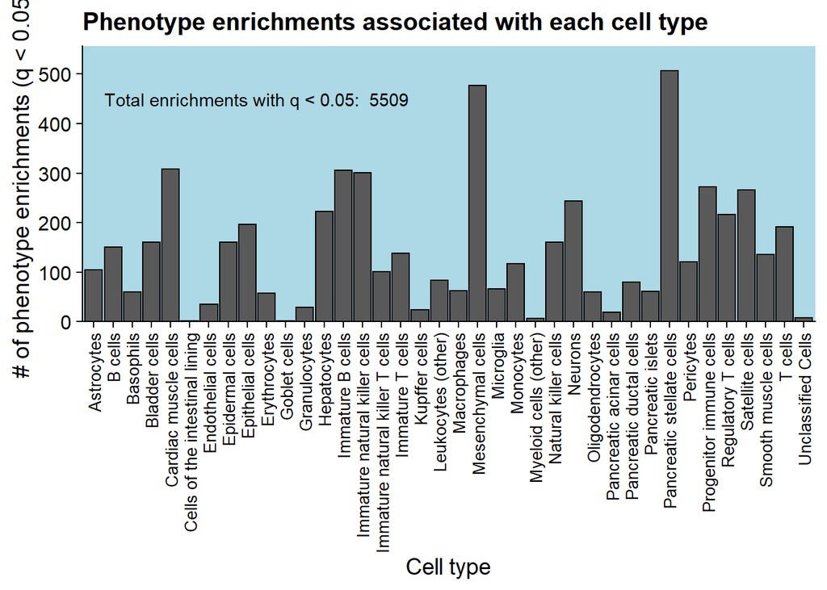

```r
EnrichedTable <- table(all_results_merged[which(all_results_merged$q < 0.05 & all_results_merged$fold_change > 1 & all_results_merged$sd_from_mean > 0), ]$CellType)
EnrichedDataFrame <- data.frame(CellType = names(EnrichedTable), ThisValue = as.numeric(EnrichedTable))
EnrichedMelt <- melt(EnrichedDataFrame)
ggplot(EnrichedMelt, aes(x = CellType, y = value)) +
  geom_bar(stat = "identity", colour = "black") + theme_cowplot() +
  theme(axis.text.x = element_text(angle = 90, vjust= 0.5, hjust = 1, size = 10)) +
  labs(title = "Phenotype enrichments associated with each cell type", x = "Cell type", y = "# of phenotype enrichments (q < 0.05)") +
  annotate("text", label = paste("Total enrichments with q < 0.05: ", sum(EnrichedTable)), x = 9.5, y = 450) +
  theme(axis.title.y = element_text(size = 14)) +
  theme(axis.title.x = element_text(size = 14)) +
  theme(title = element_text(size = 13)) +
  theme(plot.caption = element_text(vjust = 0.5, hjust = 0.1)) +
  theme(panel.background = element_rect(fill = "lightblue")) +
  scale_y_continuous(expand = expansion(mult = c(0, .1)))
```

```r
  #geom_text(aes(label = value))
```

```r
#setwd("C:/Users/jchap/OneDrive/Documents/Project_EWCE/FIGURES")
#dev.off()
MakeTotalFigure <- function(){
  ggplot(EnrichedMelt, aes(x = CellType, y = value)) +
  geom_bar(stat = "identity", colour = "black") + theme_cowplot() +
  theme(axis.text.x = element_text(angle = 90, vjust= 0.5, hjust = 1, size = 10)) +
  labs(title = "Phenotype enrichments associated with each cell type", x = "Cell type", y = "# of phenotype enrichments (q < 0.05)") +
  annotate("text", label = paste("Total enrichments with q < 0.05: ", sum(EnrichedTable)), x = 9.5, y = 450) +
  theme(axis.title.y = element_text(size = 14)) +
  theme(axis.title.x = element_text(size = 14)) +
  theme(title = element_text(size = 13)) +
  theme(plot.caption = element_text(vjust = 0.5, hjust = 0.1)) +
  theme(panel.background = element_rect(fill = "lightblue")) +
  scale_y_continuous(expand = expansion(mult = c(0, .1)))
}

MakeDiffPhenosFigure <- function(){
  ggplot(combinedSumsMelt, aes(x = ct, y = value, fill = variable)) +
  geom_bar(stat = "identity", position = "dodge") +
  theme_cowplot() +
  theme(axis.text.x = element_text(angle = 90, vjust = 0.5, hjust = 1, size = 10)) +
  ggtitle("Gene list enrichments for distinct phenotype groups") +
  labs(x = "Cell type", y = "# of enrichments (q < 0.05)") +
  scale_y_continuous(breaks = pretty_breaks(), expand = expansion(mult = c(0, .1)))
}
```

The above table shows that the highest number of significant enrichments is seen in ‘Pancreatic stellate cells’, closely followed by ‘Mesenchymal cells’.

### Searching for enrichments in phenotypes containing a specific word or phrase

It is possible to pull phenotypes from the HPO that contain specific words, phrases or terms. Following this, different sets of phenotypes can be compared against one-another to show where they fall in relation to cell populations, where enrichments are present.

For example, if we pull out any terms containing the word “heart”, any containing the word “circulating”, and any containing the word “glucose”, we can search for any enrichments associated with these phenotypes and graph them according to cell types for comparison.

Below, some basic terms associated with heart, circulation and glucose are used to pull phenotypes from the HPO. Then, the number of enrichments for each list of terms is graphed for each cell type in the dataset.

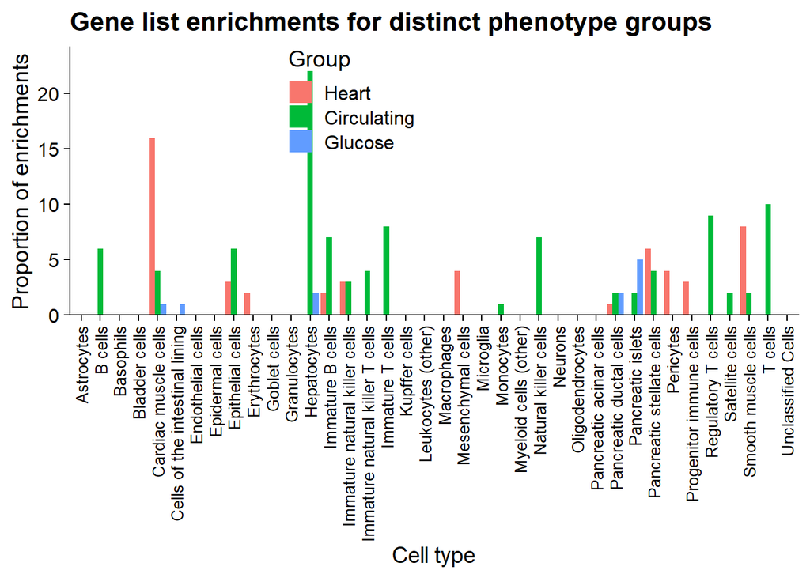

```r
HeartTerms <- c("(?i)heart|(?i)atria|(?i)aorta")
CircTerms<- c("(?i)circulating|(?i)circulate|(?i)circulation")
GlucTerms <- c("(?i)gluc|(?i)glucose")

HeartPhenos <- as.character(unique(genedata$Phenotype[str_detect(genedata$Phenotype, pattern = HeartTerms)]))
CircPhenos <- as.character(unique(genedata$Phenotype[str_detect(genedata$Phenotype, pattern = CircTerms)]))
GlucPhenos <- as.character(unique(genedata$Phenotype[str_detect(genedata$Phenotype, pattern = GlucTerms)]))

HeartSums <- table(all_results_merged[all_results_merged$list %in% HeartPhenos & all_results_merged$q < 0.05 & all_results_merged$fold_change > 1 & all_results_merged$sd_from_mean > 0, ]$CellType)
CircSums <- table(all_results_merged[all_results_merged$list %in% CircPhenos & all_results_merged$q < 0.05 & all_results_merged$fold_change > 1 & all_results_merged$sd_from_mean > 0, ]$CellType)
GlucSums <- table(all_results_merged[all_results_merged$list %in% GlucPhenos & all_results_merged$q < 0.05 & all_results_merged$fold_change > 1 & all_results_merged$sd_from_mean > 0, ]$CellType)

HeartSums2 <- HeartSums/sum(HeartSums)
CircSums2 <- CircSums/sum(CircSums)
GlucSums2 <- GlucSums/sum(GlucSums)

combinedSums <- data.frame(ct = names(HeartSums), Heart = as.numeric(HeartSums), Circulating = as.numeric(CircSums), Glucose = as.numeric(GlucSums))
combinedSums2 <- data.frame(ct = names(HeartSums2), Heart = as.numeric(HeartSums2), Circulating = as.numeric(CircSums2), Glucose = as.numeric(GlucSums2))

combinedSumsMelt <- melt(combinedSums)
combinedSumsPropMelt <- melt(combinedSums2)
combinedSumsMelt$Group <- combinedSumsMelt$variable
combinedSumsPropMelt$Group <- combinedSumsPropMelt$variable

ggplot(combinedSumsMelt, aes(x = ct, y = value, fill = Group)) + geom_bar(stat = "identity", position = "dodge") + theme_cowplot() +
  theme(axis.text.x = element_text(angle = 90, vjust = 0.5, hjust = 1, size = 10)) +
  ggtitle("Gene list enrichments for distinct phenotype groups") +
  labs(x = "Cell type", y = "Proportion of enrichments") +
  scale_y_continuous(expand = expansion(mult = c(0, .1))) +
  scale_y_continuous(breaks = pretty_breaks(), expand = expansion(mult = c(0, .1))) +
  theme(legend.position = c(0.3, 0.8))
```

For easier visualisation, we can present the data as proportions rather than absolute values:

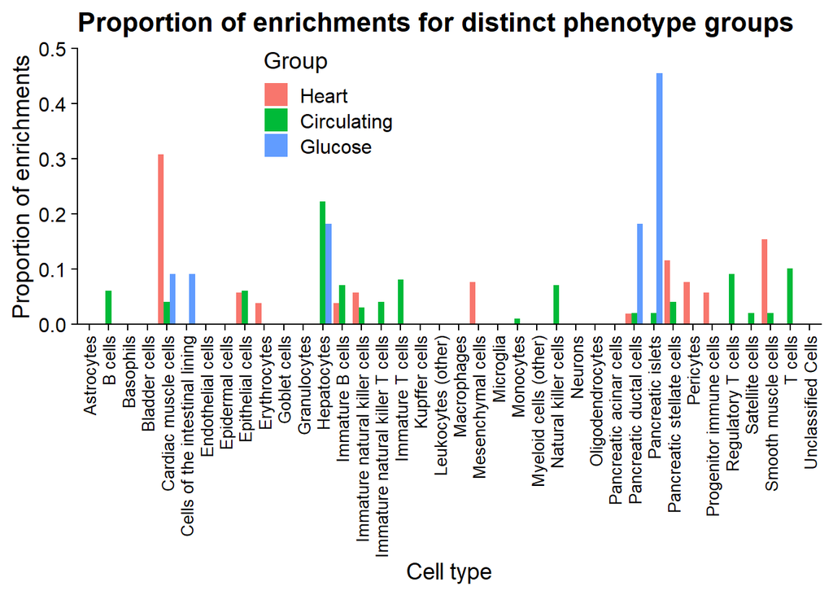

```r
ggplot(combinedSumsPropMelt, aes(x = ct, y = value, fill = Group)) + geom_bar(stat = "identity", position = "dodge") + theme_cowplot() +
  theme(axis.text.x = element_text(angle = 90, vjust = 0.5, hjust = 1, size = 10)) +
  ggtitle("Proportion of enrichments for distinct phenotype groups") +
  labs(x = "Cell type", y = "Proportion of enrichments") +
  scale_y_continuous(expand = expansion(mult = c(0, .1))) +
  scale_y_continuous(breaks = pretty_breaks(), expand = expansion(mult = c(0, .1))) +
  theme(legend.position = c(0.25, 0.8))
```

```r
sum(combinedSumsMelt$value)
```

```
## [1] 162
```

In the above graph, it can be seen that for the ‘heart’ variable, the highest proportion of significantly enriched phenotypes is associated with ‘cardiac muscle cells’, the sole cell population taken from heart tissue in Tabula Muris.

Furthermore, ‘circulating’ has the highest proportion of phenotypes in hepatocytes, and ‘glucose’ and associated terms has by far the highest proportion of phenotypes associated with the islet cells of the pancreas, as may be reasonably expected.

This method can be utilised for any number of combinations of terms, and as such is a simple method of determining where enrichments are located for ‘types’ of phenotypes.

### Searching for enrichments in phenotypes that fall under a parent term in the HPO

The Human Phenotype Ontology is structured as a directed acrylic graph. As such, it contains numerous ‘levels’ of terms ranging from rather vague (e.g. Abnormality of heart morphology) to much more specific (e.g. Left anterior fascicular block). As a general rule, terms further up in the ontology, i.e. parent terms, contain many more gene associations than their child terms, as they encompass all that fall beneath them.

Multiple R packages have been devised that allow exploration of ontologies such as the HPO. One such example is ontologyIndex, which is used in the following examples.

Using ontologyIndex, it is possible to build on the ideas above whereby specific phenotypes can be searched for in the results dataframe, by pulling all child terms underlying any given term ID. A function can be written that loops through ontologyIndex, pulling child terms and their child terms alike, until all terms that branch out from a given ID are found. Following this, the number of significant enrichements for these terms can be calculated using the results dataframe, and the number that are associated with a particular cell type can be found.

As an example, consider the following process: 1. Pull all terms that branch out from ‘Abnormality of the pancreas’. 2. Pull all significant phenotype-cell associations from the results dataframe. 3. How many of the terms under abnormality of the pancreas are significantly enriched for any cell type, and what cell types are they?

Below, we will pull all terms that fall under ‘Abnormality of the pancreas’, then use ggplot to visualise how many of these phenotypes have enrichments within the results dataframe, and what cells they are associated with.

```r
#The function to display a table
# TERM - Change this to any term in the HPO
# PROPORTION -
#         TRUE - Table represents proportion of number of phenotypes associated
#         FALSE - Table represents true number of phenotypes associated
# TABLE - Prints a table of all child terms

# Change LevelsDown within PlotDescendants to adjust how many levels down to look for child terms. Default will just find all child terms. (100 is more than enough).

PlotDescendants <- function(TERM, PROPORTION){
  INITIALID <- genedata$ID[which(genedata$Phenotype == TERM)[1]]
  INITIALIDPLACE <- which(names(children) == INITIALID)
  LevelsDown = 1000 #Just put a high number if you want all child terms
  IDs <- as.character(GetChildTerms(INITIALIDPLACE, LevelsDown, Cumulative =
  TRUE))

  df <- data.frame(matrix(nrow = length(IDs), ncol = 2))
  names(df) <- c("ID", "Term")
  df$ID <- IDs
  for(x in 1:length(df$Term)){
    df$Term[x] <- genedata$Phenotype[which(genedata$ID == df$ID[x])][1]
  }
  df <- df[-(which(is.na(df$Term))),]

  SigResults <- subset(all_results_merged, q < 0.05 & fold_change > 1 & sd_from_mean > 0)
  SigResultsTerms <- subset(SigResults, list %in% df$Term)
  Sums <- table(SigResultsTerms$CellType)
  if(PROPORTION == TRUE){
    Sums <- Sums/sum(Sums)
  }
  SumsDF <- data.frame(CellType = names(Sums), ThisTerm = as.numeric(Sums))
  SumsMelt <- reshape2::melt(SumsDF)
  print(sprintf("Total number of phenotypes: %s", sum(Sums)))
  ggplot(SumsMelt, aes(x = CellType, y = value)) + geom_bar(stat = "identity") + cowplot::theme_cowplot() + theme(axis.text.x = element_text(angle = 90, vjust = 0.5, hjust = 1, size = 10)) + labs(x = "Cell type", y = "# of enrichments (q < 0.05)") +
    theme(axis.title.y = element_text(size = 10)) +
    scale_y_continuous(breaks = pretty_breaks()) +
    geom_text(aes(label = value), data = SumsMelt[SumsMelt$value != 0, ], vjust = 1.4) +
    scale_y_continuous(expand = expansion(mult = c(0, .1))) +
    labs(title = sprintf("Number of enriched phenotypes under '%s' by cell type", TERM), caption = sprintf("Total number: %s", (sum(SumsMelt$value)))) +
    theme(plot.caption = element_text(vjust = 170, hjust = 0.1, size = 9)) +
    theme(title = element_text(size = 10)) +
    scale_y_continuous(breaks = pretty_breaks()) +
    scale_y_continuous(expand = expansion(mult = c(0, .1)), breaks = pretty_breaks())
}
```

```
## [1] "Total number of phenotypes: 20"
```

[output not shown]

[output not shown]

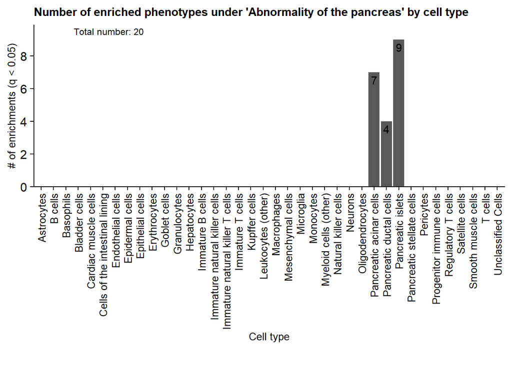

```r
PlotDescendants(TERM = "Abnormality of the pancreas", PROPORTION = FALSE)
```

The above graph shows that all terms falling under ‘Abnormality of the pancreas’, where enriched, are enriched solely in three types of pancreatic cells. Oddly, there are no enrichments associated with ‘Pancreatic stellate cells’, despite this cell type having the most enrichments in the entire set of results (see above).

#### Cell type enrichments associated with descendants of the ‘Recurrent infections’ phenotype

The same process as above can be replicated for any phenotype in the HPO. Below is the relevant plot for the ‘Recurrent infections’ phenotype.

```
## [1] "Total number of phenotypes: 59"
```

[output not shown]

[output not shown]

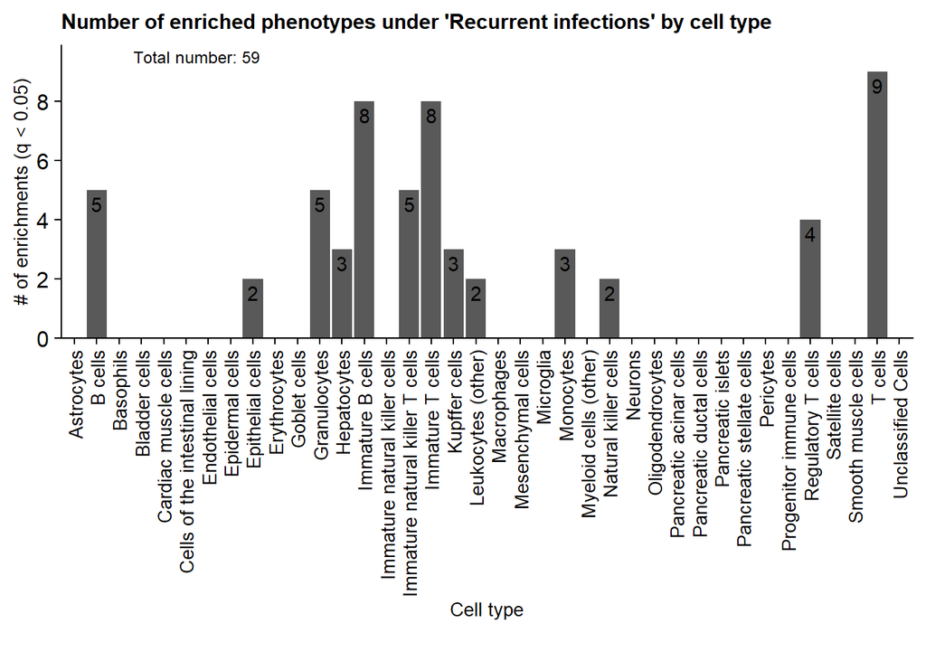

```r
PlotDescendants(TERM = "Recurrent infections", PROPORTION = FALSE)
```

As can be seen from the table, the vast majority of phenotypes under ‘Recurrent infections’, where enriched, are enriched in various immune cells. Note that there are three associated with hepatocytes, explored below.

The function ‘GiveTable’ returns a table containing every child term of the term input. This can then be used to subset all signifcant results down to those containing terms within this table.

```r
GiveTable <- function(TERM){
  INITIALID <- genedata$ID[which(genedata$Phenotype == TERM)[1]]
  INITIALIDPLACE <- which(names(children) == INITIALID)
  LevelsDown = 1000 #Just put a high number if you want all child terms
  IDs <- as.character(GetChildTerms(INITIALIDPLACE, LevelsDown, Cumulative =
  TRUE))

  df <- data.frame(matrix(nrow = length(IDs), ncol = 2))
  names(df) <- c("ID", "Term")
  df$ID <- IDs
  for(x in 1:length(df$Term)){
    df$Term[x] <- genedata$Phenotype[which(genedata$ID == df$ID[x])][1]
  }
  df <- df[-(which(is.na(df$Term))),]
  return(df)
}

signif <- subset(all_results_merged, q < 0.05 & sd_from_mean > 0 & fold_change > 1)

signif <- signif[order(signif$fold_change, decreasing = TRUE), ]

mydf <- GiveTable(TERM = "Recurrent infections")

signif[which(signif$list %in% mydf$Term), ][1:10,]
```

```
##                CellType annotLevel       p fold_change sd_from_mean
## 114291      Hepatocytes          1 0.00000   21.832879    12.182726
## 113759      Hepatocytes          1 0.00000   21.677715    11.047811
## 80966      Granulocytes          1 0.00097   14.908997     9.223949
## 78876      Granulocytes          1 0.00113   14.888795     9.199823
## 78914      Granulocytes          1 0.00105   14.778874     9.053626
## 113758    Kupffer cells          1 0.00024   13.969105    11.034995
## 114290    Kupffer cells          1 0.00015   12.866388    10.949309
## 78981  Immature T cells          1 0.00000   12.582167    14.099043
## 78976  Immature B cells          1 0.00002   11.086773    12.000943
## 114177      Hepatocytes          1 0.00005    8.805176     7.211508
##                                                list           q
## 114291              Recurrent Neisserial infections 0.000000000
## 113759              Recurrent meningococcal disease 0.000000000
## 80966     Recurrent Burkholderia cepacia infections 0.040272298
## 78876                  Recurrent E. coli infections 0.045138129
## 78914      Recurrent Serratia marcescens infections 0.042638086
## 113758              Recurrent meningococcal disease 0.013655641
## 114290              Recurrent Neisserial infections 0.009395531
## 78981              Recurrent enteroviral infections 0.000000000
## 78976              Recurrent enteroviral infections 0.001756932
## 114177 Recurrent gram-negative bacterial infections 0.003801356
```

Interestingly, in the top ten results of this list (out of 59), all three occurences of hepatocytes show up, the first two of which are extremely strong results with a fold change of almost 22 - ‘Recurrent Neisserial infections’ and ‘Recurrent meningococcal disease’.

### Leaf terms of the Human Phenotype Ontology

The HPO is a graph of associated terms whereby any individual term may have multiple parent or child terms. Using ontologyIndex again, it is possible to pull out all terms that are found to have no associated child terms. These terms are henceforth labeled ‘leaf terms’ as they are found at the ends of branches of the directed acrylic graph.

It can be assumed that any leaf terms within the ontology could be very specific to certain tissues or even cell types, and therefore will likely have fewer genes associated with them than a more broad term found higher up in the ontology.

As any given leaf term is likely to have fewer gene associations than non-leaf terms, it can be hypothesised that any cell-phenotype enrichments that flag up as significant, will be less significant and have lower fold-changes than non-leaf terms. This can be investigated by pulling the full list of leaf terms in the HPO using ontologyIndex, then generating a mean adjusted p value, as well as mean a mean fold change for any leaf terms found to have significant enrichments, when compared to non-leaf terms.

```r
LeafTerms <- children[which(lengths(children) == 0)]
LeafPhenotypes <- subset(genedata, genedata$ID %in% names(LeafTerms))
LeafPhenoList <- unique(as.list(LeafPhenotypes$Phenotype))

SigResults <- subset(all_results_merged, q < 0.05 & sd_from_mean > 0 & fold_change > 1)
SigLeafResults <- subset(SigResults, list %in% LeafPhenoList)
SigNonLeafResults <- subset(SigResults, !(list %in% LeafPhenoList))
```

From the above, we can determine the following:

- Mean fold changes:
  - Non-leaf terms: 2.6123444
  - Leaf terms: 5.6904793
- Number of significant results:
  - Non-leaf terms: 4415
  - Leaf terms: 1094

It would therefore be sensible to hypothesise that phenotypes associated with more specific tissues and cells have stronger associations with cell types when the EWCE method is used.

### Determining what cell types a group of phenotypes is associated with

Following on from where pancreatic phenotypes were linked with pancreatic cells above, a similar method can be used to determine whether certain branches of terms in the HPO are linked with cells than can be reasonably expected by logic or whether they are enriched for unexpected cells.

Consider the following as an example:

1. Pull all HPO child terms falling under ‘Abnormality of the cardiovascular system’.
2. Subset results down to significant results for a specific cell type that could be reasonably associated with those phenotypes (e.g. cardiac muscle cells for heart phenotypes).
3. Determine how many of the phenotype terms that were pulled do indeed have significant enrichment for this cell type.
4. Determine whether these enrichments make sense, and whether those enriched terms that were not child terms of the chosen branches are expected or possibly areas of interest.

```r
#First, we need to pull the list of phenotypes falling under a set of broad, but related terms

#HeartTerms <- c("Abnormal heart morphology", "Abnormal cardiomyocyte morphology", "Abnormality of the cardiovascular system", "Neoplasm of the heart", "Abnormality of the vasculature") # These are some terms manually located in the HPO that are clearly related to the heart

#HeartTerms <- unique(c(HeartTerms, unique(genedata$Phenotype[str_detect(genedata$Phenotype, pattern = "(i?)heart")])))

HeartTerms <- "Abnormality of the cardiovascular system"

PULLCHILDTERMS <- function(TERM){
  INITIALID <- genedata$ID[which(genedata$Phenotype == TERM)]
  INITIALIDPLACE <- which(names(children) == INITIALID)

  IDs <- as.character(GetChildTerms(INITIALIDPLACE, LevelsDown = 1000, Cumulative = TRUE))

  return(IDs)
}

AllIDs <- unique(unlist(lapply(HeartTerms, PULLCHILDTERMS))) #lapply utilised to pull child terms for every term contained within 'HeartTerms'
df <- data.frame(matrix(nrow = length(AllIDs), ncol = 2))
names(df) <- c("ID", "Term")
df$ID <- AllIDs
for(x in 1:length(df$Term)){
  df$Term[x] <- genedata$Phenotype[which(genedata$ID == df$ID[x])][1]
}
df <- df[-(which(is.na(df$Term))),] #Remove IDs with no associated term

#Next, we want to find all significant enrichments for 'cardiac muscle cells'

all_cardiac_signif <- subset(all_results_merged, CellType == "Cardiac muscle cells" & q < 0.05 & fold_change > 1 & sd_from_mean > 0)

#We can show how many of these are contained within the list of heart phenotypes we pulled, and how many are not.
```

```r
HeartTerms
```

```
## [1] "Abnormality of the cardiovascular system"
```

Printing the first ten rows from each results set will give some idea of the types of phenotypes associated with cardiac muscle cells:

```r
TrueHeart <- all_cardiac_signif[which(all_cardiac_signif$list %in% df$Term), ]
TrueHeart <- TrueHeart[order(TrueHeart$fold_change, decreasing = TRUE), ]
OtherHeart <- all_cardiac_signif[!which(all_cardiac_signif$list %in% df$Term), ]
OtherHeart <- OtherHeart[order(OtherHeart$fold_change, decreasing = TRUE), ]

TrueHeart
```

```
##                    CellType annotLevel       p fold_change sd_from_mean
## 150919 Cardiac muscle cells          1 0.00000   25.390396    18.521861
## 207159 Cardiac muscle cells          1 0.00000   22.485218    14.902631
## 179875 Cardiac muscle cells          1 0.00000   20.446806    17.048674
## 179799 Cardiac muscle cells          1 0.00001   20.215025    11.953080
## 168551 Cardiac muscle cells          1 0.00002   19.640415    11.520442
## 153047 Cardiac muscle cells          1 0.00000   17.401072    19.069477
## 203739 Cardiac muscle cells          1 0.00000   17.304186    19.023942
## 207083 Cardiac muscle cells          1 0.00000   17.253601    16.022266
## 43227  Cardiac muscle cells          1 0.00000   16.874715    11.003936
## 188235 Cardiac muscle cells          1 0.00000   16.603838    15.337696
## 123445 Cardiac muscle cells          1 0.00002   16.105821    11.457695
## 42201  Cardiac muscle cells          1 0.00000   15.097472    14.544404
## 111209 Cardiac muscle cells          1 0.00000   15.084272    14.424859
## 43379  Cardiac muscle cells          1 0.00000   14.981532    15.627216
```

[output cut: 183 more lines]

```r
patterns <- c("(?i)muscle|(?i)exercise|(?i)weakness|(?i)fatigue")
patternList <- as.character(OtherHeart$list[str_detect(OtherHeart$list, pattern = patterns)])
OtherHeart[which(OtherHeart$list %in% patternList)] #Which other heart terms contain the word muscle
```

```
## data frame with 0 columns and 0 rows
```

```r
OtherHeart[!which(OtherHeart$list %in% patternList)] #and which don't
```

```
## data frame with 0 columns and 0 rows
```

We can plot the results as a pie chart to show the proportions of different types of terms associated with ‘Cardiac muscle cells’:

```r
HeartDF <- data.frame(matrix(ncol = 3, nrow = 1))
colnames(HeartDF) <- c("Cardiovascular terms", "Muscle and exercise terms", "Other terms")
rownames(HeartDF) <- c("value")

HeartDF$`Cardiovascular terms` <- nrow(TrueHeart)
HeartDF$`Muscle and exercise terms` <- nrow(OtherHeart[which(OtherHeart$list %in% patternList)])
HeartDF$`Other terms` <- nrow(OtherHeart[!which(OtherHeart$list %in% patternList)])

HeartMelt <- melt(HeartDF)
```

[figure not shown]

```r
HeartBar <- ggplot(HeartMelt, aes(x = "", y = value, fill = variable)) +
  geom_bar(width = 1, stat = "identity") +
  labs(x = "Cardiac muscle cell enrichments", y = "Number of enrichments")

HeartPie <- HeartBar +
  coord_polar("y", start = 0) +
  labs(title = "Categories of HPO terms enriched in 'Cardiac muscle cells' (%)", fill = "Term type") +
  geom_text(aes(label = paste(round(value/sum(value) * 100, 1), "%")), position = position_stack(vjust = 0.5)) +
  theme_cowplot() +
  theme(plot.title = element_text(size = 12), axis.title.y = element_blank(), axis.title.x = element_blank(), axis.line = element_blank(), axis.text = element_blank(), axis.ticks = element_blank()) +
  labs(caption = paste("Total enrichments for 'Cardiac muscle cells': ", sum(HeartMelt$value)))

HeartPie
```

The list of terms that originate from branches of the heart terms can be designiated ‘true heart terms’, whereas those making up the other table are ‘alternative heart terms’.

To further analyse the difference between these true and alternate heart terms, we can once again compare p values and fold changes:

- Mean fold changes:
  - True heart terms: 9.1495948
  - Alternate heart terms: NaN
- Mean adjusted p values:
  - True heart terms: 0.0017427
  - Alternate heart terms: NaN

### Phenotypes enriched in one cell type but not another

One main feature of the Tabula Muris compendium is the inclusion of distinct populations of immune cells, including multiple types of B cells and T cells. It is therefore possible to summarise gene lists that are enriched in a particular cell, but insignificant in another.

```r
OneSignifNotAnother <- function(Yes, No){
  AllNo <- c(No)
  AllYes <- c(Yes)
  NoPhenos <- subset(all_results_merged, CellType %in% AllNo & q < 0.05 & sd_from_mean > 0 & fold_change > 1)
  NoPhenoList <- NoPhenos$list
  Not <- subset(all_results_merged, !(list %in% NoPhenoList))

  OneNotAnother <- subset(Not, CellType %in% AllYes & q < 0.05 & fold_change > 1 & sd_from_mean > 0)
  invisible(return(OneNotAnother[order(OneNotAnother$fold_change, decreasing = TRUE), ]))
}

BothSignif <- function(First, Second){
  AllFirst <- c(First)
  AllSecond <- c(Second)
  FirstPhenos <- subset(all_results_merged, CellType %in% AllFirst & q < 0.05 & fold_change > 1 & sd_from_mean > 0)
  SecondPhenos <- subset(all_results_merged, CellType %in% AllSecond & q < 0.05 & fold_change > 1 & sd_from_mean > 0)

  Both <- subset(FirstPhenos, FirstPhenos$list %in% SecondPhenos$list)
  invisible(return(Both[order(Both$fold_change, decreasing = TRUE), ]))
}

BCells <- c("B cells", "Immature B cells")
TCells <- c("Regulatory T cells", "Immature natural killer T cells", "Immature T cells", "T cells")
OneSignifNotAnother(Yes = TCells, No = BCells)[1:10, ]
```

```
##                  CellType annotLevel       p fold_change sd_from_mean
## 108680 Regulatory T cells          1 0.00000   14.221751    16.542717
## 148884 Regulatory T cells          1 0.00002   13.190085    12.399255
## 193040 Regulatory T cells          1 0.00006   11.758091    10.964983
## 207746 Regulatory T cells          1 0.00003   10.971382    11.347034
## 83790  Regulatory T cells          1 0.00001   10.459784    11.763290
## 111796 Regulatory T cells          1 0.00038    9.011143     9.086493
## 114093   Immature T cells          1 0.00003    8.210015    11.560731
## 206492 Regulatory T cells          1 0.00003    7.738230    10.252164
## 122512 Regulatory T cells          1 0.00117    7.211300     7.044894
## 94472             T cells          1 0.00016    6.798711     9.651026
##                                                                       list            q
## 108680                                    Coombs-positive hemolytic anemia 0.0000000000
## 148884                         Anti-thyroid peroxidase antibody positivity 0.0017569320
## 193040                                              Membranous nephropathy 0.0044257895
## 207746 Abnormal proportion of double-negative alpha-beta regulatory T cell 0.0024665535
## 83790                                                 Immune dysregulation 0.0009459503
## 111796                                                  Secretory diarrhea 0.0195532947
## 114093                        Decreased proportion of CD8-positive T cells 0.0024665535
## 206492                                           Recurrent gastroenteritis 0.0024665535
## 122512                                 Recurrent intrapulmonary hemorrhage 0.0463362632
## 94472                                      Decreased circulating total IgA 0.0098595545
```

```r
#OneSignifNotAnother(Yes = BCells, No = TCells)

#Result <- BothSignif(First = TCells, Second = BCells)
#Result[1:10,]
```

There are 234 sets of cell-phenotype associations strongly linked with T cells, but specifically not with B cells.

Furthermore, we can graph the total number of phenotype enrichments associated with T cells, in terms of those that are also associated with B cells, alongside those that are not.

```r
TCells <- c("Regulatory T cells", "Immature natural killer T cells", "Immature T cells", "T cells")
BCells <- c("B cells", "Immature B cells")

AllTCellEnrich <- subset(all_results_merged, q < 0.05 & sd_from_mean > 0 & fold_change > 1 & CellType %in% TCells)

TCellDF <- data.frame(matrix(ncol = 2, nrow = 1))
colnames(TCellDF) <- c("TandB", "TnotB")
rownames(TCellDF) <- c("Value")

#TCellDF$Total[1] <- nrow(AllTCellEnrich)
TCellDF$TnotB[1] <- nrow(OneSignifNotAnother(Yes = TCells, No = BCells))
TCellDF$TandB[1] <- nrow(BothSignif(First = TCells, Second = BCells))

TCellMelt <- melt(TCellDF)
TCellMelt
```

```
##   variable value
## 1    TandB   412
## 2    TnotB   234
```

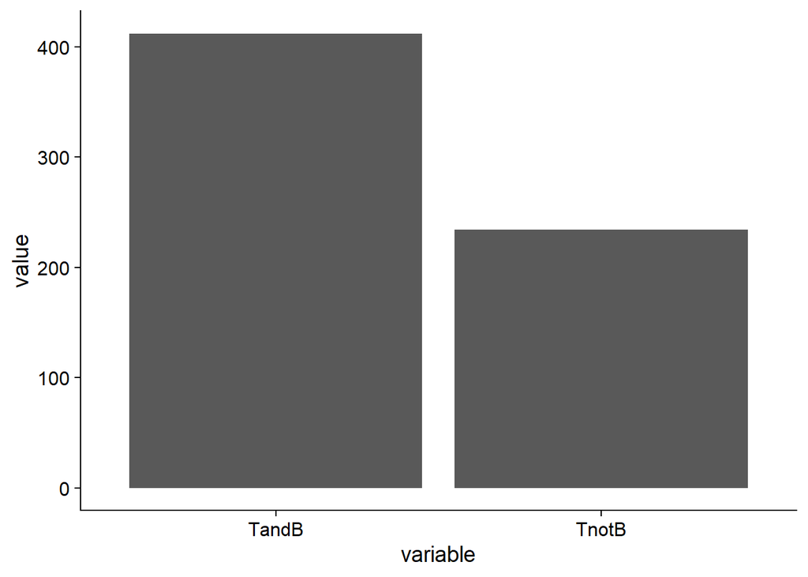

```r
ggplot(TCellMelt, aes(x = variable, y = value)) +
  geom_bar(stat = "identity") +
  theme_cowplot()
```